# Tarea1_Natalia_Bonilla_V2

## Tarea 1

Programa Experto en Inteligencia Artificial con Python  
ML2000 - Métodos No Supervisados  
Estudiante: Natalia Bonilla Villalobos.

[output not shown]

```python
import numpy as np
import pandas as pd
import seaborn as sns
import matplotlib.pyplot as plt
# import prince
from prince import PCA as pca_prince
from sklearn.decomposition import PCA
from sklearn.datasets import load_digits
from sklearn.preprocessing import StandardScaler
```

# Ejercicio 1

[10 puntos] Que es más exacto: las correlaciones que se obtienen usando el metodo `corr` o las obtenidas en el círculo de correlación? Debe brindar una explicación a su respuesta.

↑ Volver al Menú

Ambas funcionan de manera distinta al dar un resultado `.corr()` nos va a dar un número mas preciso porque calcula la correlación directamente de los datos sin perder información (Muestra correlaciones entre **variables originales**). Proporciona un valor numérico preciso. Mientras que el Circulo de correlaciones es menos "exacto" matematicamente hablando por que es una aproximación visual de las correlaciones (Muestra correlaciones **variables-componentes**). Su precision depende de la varianza explocada por los componentes principales usados.

- Ambas tienen su enfoque:
  - **.corr()**: Usada para evaluar fuerza y direccoin de la relación lineal entre dos variables. Resultado de R es un coeficiente que varia entre -1 y 1 indicando una realcion lineal negativa o positiva, o ninguna relacion (0). Además para realizar pruebas estadisticas y determinar el significado de la correlacion representado por un valor p (p-value).
  - **Circulo de correlación**: Usada para visualizar y explorar relaciones entre varias variables a la vez. Útil para identificar rapidamente patrones, variables altamente correlacionadas y grupos de variables que se mueven juntas. En el contexto de un modelo de un PCA, el círculo de correlación es la herramienta principal porque te muestra cómo las **variables originales** se relacionan con las **nuevas dimensiones** (los PCA).
- Usas `.corr()` para un análisis y el círculo para interpretar el PCA.

Ejemplo, si tenemos variables: `ansiedad`, `sueño`, `depresión`:

**.corr() dice:**

- `ansiedad` se correlaciona X con `sueño`
- `ansiedad` se correlaciona Y con `depresión`
- `sueño` se correlaciona Z con `depresión`

**Círculo de correlación dice:**

- `ansiedad` tiene correlación A con Componente 1 del PCA
- `sueño` tiene correlación B con Componente 1 del PCA
- `depresión` tiene correlación C con Componente 2 del PCA

# Ejercicio 2

[10 puntos] Utilice el conjunto de datos `StressLevel.csv`. Este conjunto contiene información obtenida de una encuesta a estudiantes universitarios, con el objetivo de identificar factores asociados al estrés académico. La tabla cuenta con `N` filas (estudiantes) y 20 variables predictoras, descritas a continuación:

- **Factores psicológicos:**
  - `anxiety level`: Nivel de ansiedad reportado. Escala numerica discreta (mayores valores = más ansiedad).
  - `self esteem`: Nivel de autoestima. Escala numerica discreta (valores altos = mayor autoestima).
  - `mental health history`: Antecedentes de salud mental (0 = No, 1 = Sí). Variable categórica binaria.
  - `depression`: Puntaje de síntomas depresivos. Numerica discreta (valores altos = mayor depresión).
- **Factores fisiológicos:**
  - `headache`: Frecuencia de dolores de cabeza. Categórica ordinal (0 = nunca, 5 = muy frecuente).
  - `blood pressure`: Nivel de presión arterial. Categórica ordinal (1 = baja, 2 = normal, 3 = alta).
  - `sleep quality`: Calidad del sueño. Categórica ordinal (0 = muy mala, 5 = muy buena).
  - `breathing problem`: Presencia de problemas respiratorios. Categórica ordinal (0 = nunca, 5 = muy frecuente).
- **Factores ambientales:**
  - `noise level`: Nivel de ruido en el entorno. Categórica ordinal (0 = bajo, 5 = muy alto).
  - `living conditions`: Condiciones de vida del estudiante. Categórica ordinal (0 = muy malas, 5 = muy buenas).
  - `safety`: Percepción de seguridad en el entorno. Categórica ordinal (0 = nada seguro, 5 = muy seguro).
  - `basic needs`: Grado de satisfacción de necesidades básicas (alimentación, vivienda). Categórica ordinal (0 = insatisfechas, 5 = totalmente satisfechas).
- **Factores académicos:**
  - `academic performance`: Confianza en el rendimiento académico. Categórica ordinal (0 = muy baja, 5 = muy alta).
  - `study load`: Percepción de la carga académica. Categórica ordinal (0 = muy ligera, 5 = muy pesada).
  - `teacher student relationship`: Calidad de la relación con los profesores. Categórica ordinal (0 = muy mala, 5 = muy buena).
  - `future career concerns`: Preocupación por la carrera futura. Categórica ordinal (0 = nada preocupado, 5 = muy preocupado).
- **Factores sociales:**
  - `social support`: Nivel de apoyo social percibido. Categórica ordinal (0 = muy bajo, 5 = muy alto).
  - `peer pressure`: Presión ejercida por los pares. Categórica ordinal (0 = nula, 5 = muy alta).
  - `extracurricular activities`: Participación en actividades extracurriculares. Categórica ordinal (0 = nula, 5 = muy alta).
  - `bullying`: Presencia de acoso escolar. Categórica ordinal (0 = nunca, 5 = muy frecuente).
- **Variable objetivo:**
  - `stress type`: Tipo de estrés que experimenta principalmente el estudiante. Variable categórica con tres clases posibles: No Stress = 0, Eustress = 1, Distress = 2.

**Realice lo siguiente:**

- a) Calcule el resumen numérico, interprete los resultados para dos variables.
- b) Calcule la matriz de correlaciones, incluya un gráfico e interprete dos de las correlaciones. Debe ser una interpretación amplia y detallada para una persona que no conoce nada del tema.

↑ Volver al Menú

## Parte 1

Calcule el resumen numérico, interprete los resultados para dos variables.

```python
df_2 = pd.read_csv('../StressLevel.csv')
df_2.head(5)
```

|  | anxiety_level | self_esteem | mental_health_history | depression | headache | blood_pressure | sleep_quality | breathing_problem | noise_level | living_conditions | ... | basic_needs | academic_performance | study_load | teacher_student_relationship | future_career_concerns | social_support | peer_pressure | extracurricular_activities | bullying | stress_level |
| --- | --- | --- | --- | --- | --- | --- | --- | --- | --- | --- | --- | --- | --- | --- | --- | --- | --- | --- | --- | --- | --- |
| 0 | 14 | 20 | 0 | 11 | 2 | 1 | 2 | 4 | 2 | 3 | ... | 2 | 3 | 2 | 3 | 3 | 2 | 3 | 3 | 2 | 1 |
| 1 | 15 | 8 | 1 | 15 | 5 | 3 | 1 | 4 | 3 | 1 | ... | 2 | 1 | 4 | 1 | 5 | 1 | 4 | 5 | 5 | 2 |
| 2 | 12 | 18 | 1 | 14 | 2 | 1 | 2 | 2 | 2 | 2 | ... | 2 | 2 | 3 | 3 | 2 | 2 | 3 | 2 | 2 | 1 |
| 3 | 16 | 12 | 1 | 15 | 4 | 3 | 1 | 3 | 4 | 2 | ... | 2 | 2 | 4 | 1 | 4 | 1 | 4 | 4 | 5 | 2 |
| 4 | 16 | 28 | 0 | 7 | 2 | 3 | 5 | 1 | 3 | 2 | ... | 3 | 4 | 3 | 1 | 2 | 1 | 5 | 0 | 5 | 1 |

5 rows × 21 columns

```python
df_2.columns
```

```
Index(['anxiety_level', 'self_esteem', 'mental_health_history', 'depression',
       'headache', 'blood_pressure', 'sleep_quality', 'breathing_problem',
       'noise_level', 'living_conditions', 'safety', 'basic_needs',
       'academic_performance', 'study_load', 'teacher_student_relationship',
       'future_career_concerns', 'social_support', 'peer_pressure',
       'extracurricular_activities', 'bullying', 'stress_level'],
      dtype='object')
```

```python
df_2.describe()
```

|  | anxiety_level | self_esteem | mental_health_history | depression | headache | blood_pressure | sleep_quality | breathing_problem | noise_level | living_conditions | ... | basic_needs | academic_performance | study_load | teacher_student_relationship | future_career_concerns | social_support | peer_pressure | extracurricular_activities | bullying | stress_level |
| --- | --- | --- | --- | --- | --- | --- | --- | --- | --- | --- | --- | --- | --- | --- | --- | --- | --- | --- | --- | --- | --- |
| count | 1100.000000 | 1100.000000 | 1100.000000 | 1100.000000 | 1100.000000 | 1100.000000 | 1100.000000 | 1100.000000 | 1100.000000 | 1100.000000 | ... | 1100.000000 | 1100.000000 | 1100.000000 | 1100.000000 | 1100.000000 | 1100.000000 | 1100.000000 | 1100.000000 | 1100.000000 | 1100.000000 |
| mean | 11.063636 | 17.777273 | 0.492727 | 12.555455 | 2.508182 | 2.181818 | 2.660000 | 2.753636 | 2.649091 | 2.518182 | ... | 2.772727 | 2.772727 | 2.621818 | 2.648182 | 2.649091 | 1.881818 | 2.734545 | 2.767273 | 2.617273 | 0.996364 |
| std | 6.117558 | 8.944599 | 0.500175 | 7.727008 | 1.409356 | 0.833575 | 1.548383 | 1.400713 | 1.328127 | 1.119208 | ... | 1.433761 | 1.414594 | 1.315781 | 1.384579 | 1.529375 | 1.047826 | 1.425265 | 1.417562 | 1.530958 | 0.821673 |
| min | 0.000000 | 0.000000 | 0.000000 | 0.000000 | 0.000000 | 1.000000 | 0.000000 | 0.000000 | 0.000000 | 0.000000 | ... | 0.000000 | 0.000000 | 0.000000 | 0.000000 | 0.000000 | 0.000000 | 0.000000 | 0.000000 | 0.000000 | 0.000000 |
| 25% | 6.000000 | 11.000000 | 0.000000 | 6.000000 | 1.000000 | 1.000000 | 1.000000 | 2.000000 | 2.000000 | 2.000000 | ... | 2.000000 | 2.000000 | 2.000000 | 2.000000 | 1.000000 | 1.000000 | 2.000000 | 2.000000 | 1.000000 | 0.000000 |
| 50% | 11.000000 | 19.000000 | 0.000000 | 12.000000 | 3.000000 | 2.000000 | 2.500000 | 3.000000 | 3.000000 | 2.000000 | ... | 3.000000 | 2.000000 | 2.000000 | 2.000000 | 2.000000 | 2.000000 | 2.000000 | 2.500000 | 3.000000 | 1.000000 |
| 75% | 16.000000 | 26.000000 | 1.000000 | 19.000000 | 3.000000 | 3.000000 | 4.000000 | 4.000000 | 3.000000 | 3.000000 | ... | 4.000000 | 4.000000 | 3.000000 | 4.000000 | 4.000000 | 3.000000 | 4.000000 | 4.000000 | 4.000000 | 2.000000 |
| max | 21.000000 | 30.000000 | 1.000000 | 27.000000 | 5.000000 | 3.000000 | 5.000000 | 5.000000 | 5.000000 | 5.000000 | ... | 5.000000 | 5.000000 | 5.000000 | 5.000000 | 5.000000 | 3.000000 | 5.000000 | 5.000000 | 5.000000 | 2.000000 |

8 rows × 21 columns

### Resultados

- El conjunto de datos `StressLevel.csv` contiene 1100 filas y 21 columnas.
- Variable `anxiety_level`: Nivel de ansiedad reportado. Escala numerica discreta (mayores valores = más ansiedad). En una escala de 0 (min) a 21 (max). El nivel de ansiedad reportado tiene un promedio de 11.06 (poco más de la mitad en la escala) y una desviación estándar de 6.11. La mitad de los estudiantes universitarios tienen un nivel de ansiedad igual o menor a 11.
- Variable `breathing_problem`: Presencia de problemas respiratorios. Categórica ordinal (0 = nunca, 5 = muy frecuente). El nivel de problema respiratorio reportado tiene un promedio de 2.75 (o sea, es más o menos frecuente) y una desviación estándar de 1.40. La mitad de los estudiantes universitarios tienen un nivel de problema respiratorio igual o menor a 3.

## Parte 2

Calcule la matriz de correlaciones, incluya un gráfico e interprete dos de las correlaciones. Debe ser una interpretación amplia y detallada para una persona que no conoce nada del tema.

```python
matriz = df_2.corr()
matriz.head(5)
```

|  | anxiety_level | self_esteem | mental_health_history | depression | headache | blood_pressure | sleep_quality | breathing_problem | noise_level | living_conditions | ... | basic_needs | academic_performance | study_load | teacher_student_relationship | future_career_concerns | social_support | peer_pressure | extracurricular_activities | bullying | stress_level |
| --- | --- | --- | --- | --- | --- | --- | --- | --- | --- | --- | --- | --- | --- | --- | --- | --- | --- | --- | --- | --- | --- |
| anxiety_level | 1.000000 | -0.672745 | 0.634450 | 0.694340 | 0.632738 | 0.330867 | -0.710292 | 0.561654 | 0.608624 | -0.568434 | ... | -0.637079 | -0.649601 | 0.586064 | -0.663176 | 0.717016 | -0.569748 | 0.642910 | 0.641022 | 0.709982 | 0.736795 |
| self_esteem | -0.672745 | 1.000000 | -0.603502 | -0.699602 | -0.626058 | -0.514692 | 0.662693 | -0.510514 | -0.571169 | 0.550535 | ... | 0.631212 | 0.639045 | -0.575112 | 0.652934 | -0.712520 | 0.679211 | -0.607118 | -0.641202 | -0.640737 | -0.756195 |
| mental_health_history | 0.634450 | -0.603502 | 1.000000 | 0.615882 | 0.604826 | 0.295617 | -0.614146 | 0.464347 | 0.515290 | -0.508525 | ... | -0.601196 | -0.586193 | 0.532267 | -0.587728 | 0.625909 | -0.482560 | 0.580602 | 0.554576 | 0.624366 | 0.648644 |
| depression | 0.694340 | -0.699602 | 0.615882 | 1.000000 | 0.657700 | 0.436084 | -0.693161 | 0.522540 | 0.566250 | -0.530351 | ... | -0.608776 | -0.633174 | 0.602498 | -0.673853 | 0.706561 | -0.617972 | 0.635544 | 0.648551 | 0.665790 | 0.734379 |
| headache | 0.632738 | -0.626058 | 0.604826 | 0.657700 | 1.000000 | 0.361986 | -0.638771 | 0.461719 | 0.543557 | -0.532825 | ... | -0.623199 | -0.622059 | 0.542890 | -0.625928 | 0.679307 | -0.572988 | 0.622581 | 0.582562 | 0.609775 | 0.713484 |

5 rows × 21 columns

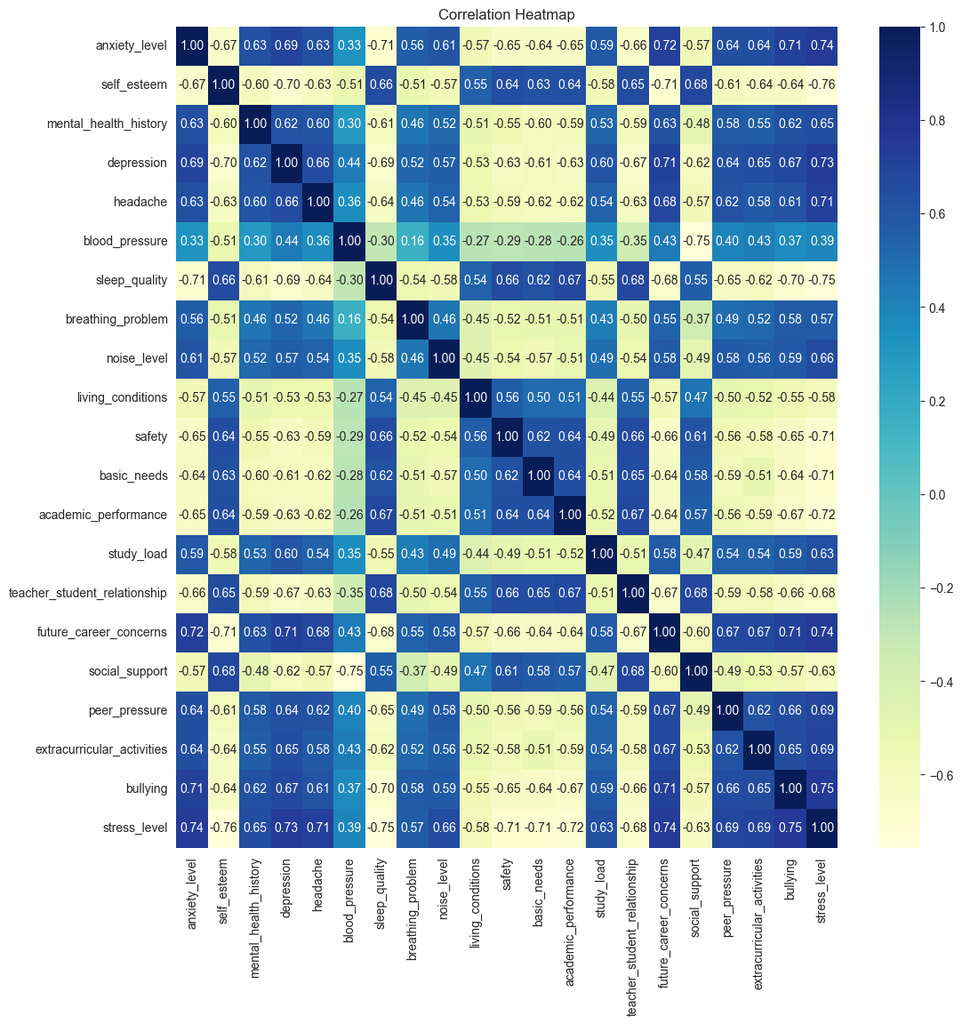

```python
plt.figure(figsize=(12,12))
sns.heatmap(matriz, annot=True, cmap="YlGnBu", fmt='.2f')
plt.title('Correlation Heatmap')
plt.show()
```

### Resultados

- Se observa una correlación positiva fuerte entre el `bullying` y el `stress_level` con un 0.75 muy cercano a 1. Esto significa que a medida que los estudiantes universitarios reportan que son víctimas de bullying, también tienden a reportar mayores niveles de estrés. Esto sugiere que ambas condiciones están muy relacionadas de manera positiva, **entre más acoso, más estrés**.
- Podemos observar una correlacion negativa fuerte entre `self_esteem` y `depression` con un -0.70 muy cercano a -1. Lo que significa que a medidad que los estudiantes universitarios tienen mayor autoestima tienen menos síntomas de depresión. Estas condiciones estan altamente relacionadas pero de manera negativa, **a mayor autoestima, menor depresión.**

# Ejercicio 3

[30 puntos] Utilizando nuevamente los datos `StressLevel.csv`, realice lo siguiente:

- a) Efectúe un ACP utilizando todas las variables correspondientes a los factores psicológicos, ambientales y todas las varibles de otro factor de su elección.
- b) En el plano principal, identifíque al menos 3 clústeres.
- c) En el círculo de correlación, interprete al menos dos correlaciones entre variables de distintos factores.
- d) Identifíque e interprete la formación de clústeres basándose en la superposición del círculo y el plano. Debe indicar cuáles son las variables que caracterizan los grupos formados anteriormente.

↑ Volver al Menú

## Parte 1

Efectúe un ACP utilizando todas las variables correspondientes a los factores psicológicos, ambientales y todas las varibles de otro factor de su elección.

```python
df_pca = df_2.copy()
df_pca = df_pca[['anxiety_level', 'self_esteem', 'mental_health_history', 'depression','noise_level', 'living_conditions', 'safety', 'basic_needs', 'academic_performance', 'study_load', 'teacher_student_relationship','future_career_concerns']]
df_pca.head(5)
```

|  | anxiety_level | self_esteem | mental_health_history | depression | noise_level | living_conditions | safety | basic_needs | academic_performance | study_load | teacher_student_relationship | future_career_concerns |
| --- | --- | --- | --- | --- | --- | --- | --- | --- | --- | --- | --- | --- |
| 0 | 14 | 20 | 0 | 11 | 2 | 3 | 3 | 2 | 3 | 2 | 3 | 3 |
| 1 | 15 | 8 | 1 | 15 | 3 | 1 | 2 | 2 | 1 | 4 | 1 | 5 |
| 2 | 12 | 18 | 1 | 14 | 2 | 2 | 3 | 2 | 2 | 3 | 3 | 2 |
| 3 | 16 | 12 | 1 | 15 | 4 | 2 | 2 | 2 | 2 | 4 | 1 | 4 |
| 4 | 16 | 28 | 0 | 7 | 3 | 2 | 4 | 3 | 4 | 3 | 1 | 2 |

```python
pca_model = pca_prince(n_components=2,
                       n_iter=3, #se usa internamente para encontrar los componentes principales, numero de iteraciones que hará el algoritmo.
                       rescale_with_mean=True, # centrar los datos, a cada valor de cada variable se le resta la media de esa variable.
                       rescale_with_std=True, # escala los datos, dividiendo cada valor por la desviación estándar de la variable.
                       copy=True, # Trabajar con una copia de los datos, esto es útil para no modificar accidentalmente el df original
                       engine='sklearn' )
pca_model = pca_model.fit(df_pca)
pca_model
```

```
PCA()
```

## Parte 2

En el plano principal, identifíque al menos 3 clústeres.

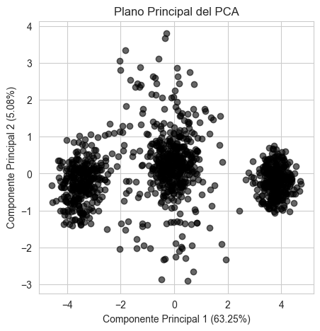

```python
# Obtener las coordenadas de los individuos
coordenadas_individuos = pca_model.row_coordinates(df_pca)
inercia_x = round(pca_model.percentage_of_variance_[0],2)
inercia_y = round(pca_model.percentage_of_variance_[1],2)
# Crear el gráfico del plano principal
plt.figure(figsize=(5, 5))  #Define el tamaño de la figura en la que se va a dibujar el gráfico
plt.scatter(coordenadas_individuos[0], # El eje X del gráfico será el Componente Principal 1 (la que explica más varianza)
            coordenadas_individuos[1], # El eje Y será el Componente Principal 2
            c='black', # Para colorear los puntos de los individuos
            alpha=0.6)
plt.title('Plano Principal del PCA')
plt.xlabel(f'Componente Principal 1 ({inercia_x}%)')
plt.ylabel(f'Componente Principal 2 ({inercia_y}%)')
plt.grid(True)
plt.show()
```

### Resultados

Podemos identificar 3 grupos densos de puntos, estos se visualizan:

- El primer grupo a la izquierda del grafico
- El segundo grupo, en el centro. Este es bastante denso sin embargo, podemos ver que tiene grupos menos focalizados a lo largo de este.
- El tercer grupo, a la derecha del gráfico, este esta mucho mas condensado que los otros 2.

## Parte 3

En el círculo de correlación, interprete al menos dos correlaciones entre variables de distintos factores.

```python
def graficar_circulo_correlacion(x, y, inercia_x, inercia_y,
                                 etiquetas=None,
                                 comp_x=1, comp_y=2,
                                 titulo_x="Componente", titulo_y="Componente"):
    x = np.asarray(x, dtype=float)
    y = np.asarray(y, dtype=float)
    n = len(x)
    if etiquetas is None:
        etiquetas = [str(i) for i in range(n)]

    fig, ax = plt.subplots(figsize=(10, 10))

    # Vectores (flechas) y etiquetas
    for i in range(n):
        ax.arrow(0, 0, x[i], y[i],
                 color='steelblue', alpha=0.5,
                 head_width=0.05, head_length=0.05, length_includes_head=True)
        ax.text(x[i]*1.05, y[i]*1.05, etiquetas[i],
                color='black', ha='center', va='center')

    # Círculo unidad
    circulo = plt.Circle((0, 0), radius=1, color='steelblue', fill=False)
    ax.add_artist(circulo)

    # Formato del plano
    ax.axis('scaled')
    ax.set_xlim(-1, 1)
    ax.set_ylim(-1, 1)
    ax.axhline(y=0, color='dimgrey', linestyle='--')
    ax.axvline(x=0, color='dimgrey', linestyle='--')

    # Ejes con inercia
    ax.set_xlabel(f"{titulo_x} {comp_x} ({round(inercia_x, 2)}%)")
    ax.set_ylabel(f"{titulo_y} {comp_y} ({round(inercia_y, 2)}%)")

    plt.show()
```

```python
variables = pca_model.column_correlations
variables
```

| component variable | 0 | 1 |
| --- | --- | --- |
| anxiety_level | -0.850838 | -0.044255 |
| self_esteem | 0.837309 | 0.030112 |
| mental_health_history | -0.771185 | -0.097054 |
| depression | -0.837948 | -0.113853 |
| noise_level | -0.724666 | -0.229128 |
| living_conditions | 0.701148 | -0.418679 |
| safety | 0.804457 | -0.250972 |
| basic_needs | 0.800625 | -0.045355 |
| academic_performance | 0.804242 | -0.115118 |
| study_load | -0.713572 | -0.499584 |
| teacher_student_relationship | 0.824734 | -0.167624 |
| future_career_concerns | -0.852475 | -0.008147 |

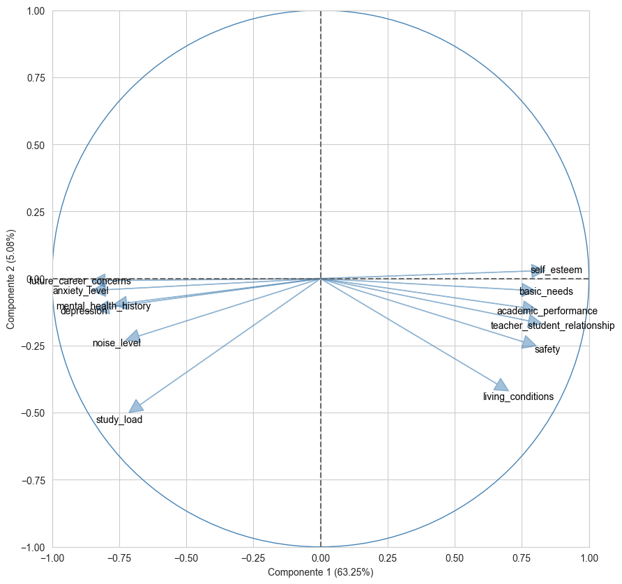

```python
x = variables.iloc[:, 0] # Dimensión 1
y = variables.iloc[:, 1] # Dimensión 2
etiquetas = variables.index
graficar_circulo_correlacion(x, y, inercia_x, inercia_y,
                             etiquetas=etiquetas,
                             comp_x=1, comp_y=2,
                             titulo_x="Componente", titulo_y="Componente")
```

## Parte 4

Identifíque e interprete la formación de clústeres basándose en la superposición del círculo y el plano. Debe indicar cuáles son las variables que caracterizan los grupos formados anteriormente.

```python
def graficar_sobreposicion(x_ind, y_ind, x_var, y_var,
                          inercia_x, inercia_y,
                          etiquetas_individuos=None, etiquetas_variables=None,
                          comp_x=1, comp_y=2,
                          titulo_x="Componente", titulo_y="Componente"):

    # --- preparar datos ---
    x_ind = np.asarray(x_ind, dtype=float)
    y_ind = np.asarray(y_ind, dtype=float)
    x_var = np.asarray(x_var, dtype=float)
    y_var = np.asarray(y_var, dtype=float)

    n_ind = len(x_ind)
    n_var = len(x_var)

    if etiquetas_individuos is None:
        etiquetas_individuos = [str(i) for i in range(n_ind)]
    if len(etiquetas_individuos) != n_ind:
        raise ValueError("`etiquetas_individuos` debe tener la misma longitud que x_ind/y_ind.")

    if etiquetas_variables is None:
        etiquetas_variables = [str(i) for i in range(n_var)]
    if len(etiquetas_variables) != n_var:
        raise ValueError("`etiquetas_variables` debe tener la misma longitud que x_var/y_var.")

    # --- escala para flechas ---
    rx  = np.ptp(x_ind)
    ry  = np.ptp(y_ind)
    rvx = np.ptp(x_var) if np.ptp(x_var) > 0 else 1.0
    rvy = np.ptp(y_var) if np.ptp(y_var) > 0 else 1.0
    scale = 0.7 * min(rx / rvx, ry / rvy) if (rvx > 0 and rvy > 0) else 0.7

    # --- gráfico ---
    fig, ax = plt.subplots(figsize=(10, 10))

    # nube de individuos
    ax.scatter(x_ind, y_ind, color='steelblue', alpha=0.6)

    # etiquetas de individuos
    # for i in range(n_ind):
    #     ax.annotate(etiquetas_individuos[i], (x_ind[i], y_ind[i]))

    # flechas y etiquetas de variables
    for j in range(n_var):
        ax.arrow(0, 0, x_var[j]*scale, y_var[j]*scale,
                 color='darkblue', alpha=0.5,
                 head_width=0.05, head_length=0.05, length_includes_head=True)
        ax.text(x_var[j]*scale, y_var[j]*scale, etiquetas_variables[j],
                color='black', ha='center', va='center')

    # ejes base y rótulos
    ax.axhline(y=0, color='dimgrey', linestyle='--')
    ax.axvline(x=0, color='dimgrey', linestyle='--')
    ax.set_xlabel(f"{titulo_x} {comp_x} ({round(inercia_x, 2)}%)")
    ax.set_ylabel(f"{titulo_y} {comp_y} ({round(inercia_y, 2)}%)")

    plt.show()
```

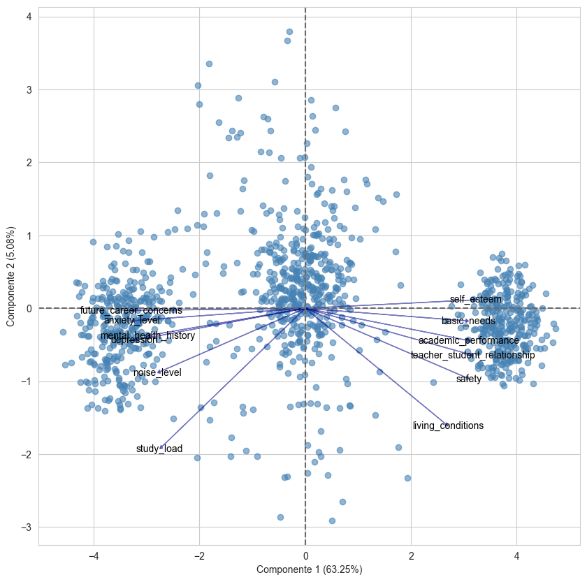

```python
individuos = pca_model.row_coordinates(df_pca)
variables  = pca_model.column_correlations
x_ind = individuos.iloc[:, 0]
y_ind = individuos.iloc[:, 1]
x_var = variables.iloc[:, 0]
y_var = variables.iloc[:, 1]
inercia_x = pca_model.percentage_of_variance_[0]
inercia_y = pca_model.percentage_of_variance_[1]
et_ind = individuos.index
et_var = variables.index

graficar_sobreposicion(x_ind, y_ind, x_var, y_var,
                      inercia_x, inercia_y,
                      etiquetas_individuos=et_ind,
                      etiquetas_variables=et_var,
                      comp_x=1, comp_y=2)
```

### Resultados

- El grupo izquerdo esta representado por `future_career_concerns`, `anxiety_level`, `mental_healt_history`, `depression`, `noise_level` y un poco mas alejado del grupo `study_load`, por lo tanto este grupo se carateriza por tener altos niveles de depresión, ansiedad, preocupaciones profesionales futuras y un historial de salud mental y un poco alejado la carga de estudio, aunque éste esta del lado izquierdo se aleja bastante del grupo izq.
- El grupo central no tiene representación fuerte de las variables, de aquí se originan las variables que van a los extremos, entonces se podria decir que tienen valores promedio.
- El grupo derecho, esta conformado por `self_steem`, `basic_needs`, `academic_performance`, `teacher_student_relationship`, `safety` y un poco mas lejano del cluster `living_conditions`. por lo que este grupo se carateriza por tener alta autoestima, rendimiento academico, buena relación estudiante-profesor, tienen una buena ércepcion de la sguridad.

# Ejercicio 4

[20 puntos] Profundizando el análisis de los clústeres obtenidos previamente, incorpore la variable objetivo `stress type` y realice lo siguiente:

- a) Utilice la variable `stress type` como referencia externa para interpretar los clústeres identificados en el plano principal. Para ello, represente los puntos del gráfico de ACP coloreados según el tipo de estrés reportado por los estudiantes (`No Stress`, `Eustress`, `Distress`).
- b) Analice cómo se distribuyen las distintas clases de estrés en los clústeres formados. Se observa alguna tendencia o agrupación predominante según el tipo de estrés? Qué relación puede establecerse entre los clústeres y los tipos de estrés?
- c) Proponga una interpretación razonada sobre qué variables podrán estar explicando la presencia de cada tipo de estrés en los clústeres. Fundamente su respuesta a partir de la información disponible en el plano principal y el círculo de correlación.

↑ Volver al Menú

### Parte 1

Utilice la variable `stress type` como referencia externa para interpretar los clústeres identificados en el plano principal. Para ello, represente los puntos del gráfico de ACP coloreados según el tipo de estrés reportado por los estudiantes (`No Stress`, `Eustress`, `Distress`).

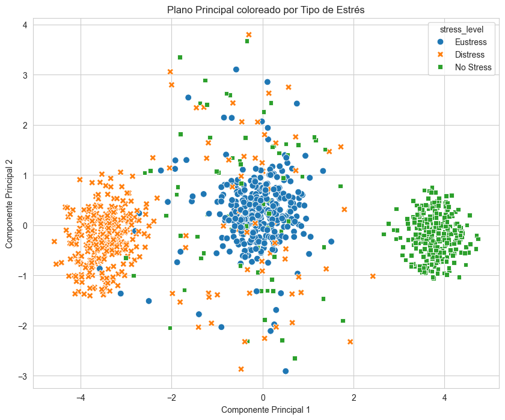

```python
stress_level = df_2['stress_level']

# Mapear los nombres de los clústeres para la leyenda
mapeo_estres = {0: 'No Stress', 1: 'Eustress', 2: 'Distress'}
stress_level_mapeado = stress_level.map(mapeo_estres)

# Crear un DataFrame para facilitar el gráfico con seaborn
df_plot = coordenadas_individuos.copy()
df_plot['stress_level'] = stress_level_mapeado
df_plot.columns = ['PC1', 'PC2', 'stress_level']

plt.figure(figsize=(10, 8))
# Usamos 'stress_level' como la variable para colorear los puntos
sns.scatterplot(x='PC1', # Componente Principal 1
                y='PC2', # Componente Principal 2
                hue='stress_level', # Color de los puntos
                # palette='viridis',
                data=df_plot,
                style='stress_level', # estilo y la forma de los puntos
                s=60) # tamaño de los puntos
plt.title('Plano Principal coloreado por Tipo de Estrés')
plt.xlabel('Componente Principal 1')
plt.ylabel('Componente Principal 2')
plt.grid(True)
plt.show()
```

### Parte 2

Analice cómo se distribuyen las distintas clases de estrés en los clústeres formados. Se observa alguna tendencia o agrupación predominante según el tipo de estrés? Qué relación puede establecerse entre los clústeres y los tipos de estrés?

- El cluster izquierdo, esta conformado por `Distress`: que es una clase negativa del estres que causa malestar y pyede afectar la salud fisica y mental.
- El cluster central, esta conformado por una combinación de las 3 clases de stress, pero tiene su mayor agrupación por `Eustress`: un tipo de estres positivo que puede ser beneficioso para la motivación y el rendimiento.
- El cluster derecho, esta conformado por `No stress`: conformado por un grupo denso de estudiantes sin estres.

### Parte 3

Proponga una interpretación razonada sobre qué variables podrán estar explicando la presencia de cada tipo de estrés en los clústeres. Fundamente su respuesta a partir de la información disponible en el plano principal y el círculo de correlación.

- El cluster izquierdo está dominado por `Distress`. Los estudiantes con el tipo de estres negativo `Distress` tienden a ser los que se ven afectados por factores como la ansiedad, la depresión, la preocupación por la carrera, y el ruido en el entorno. El componente principal 1, que tiene una alta correlación con estas variables, parece ser un eje de `distress` o carga psicológica, por sus variables: `future_career_concerns`, `anxiety_level`, `mental_health_history`, `depression`, `noise_level` y `study_load`
- El cluster central está dominado por `Eustress`, el cual no está tan ligada a las variables que definen los extremos del plano. Los estudiantes que experimentan este tipo de estrés positivo tienen un perfil más "promedio" en cuanto a la ansiedad, depresión. Esto podría sugerir que el `Eustress` podría estar más relacionado con otros factores que no están tan bien representados en este plano.
- El cluster derecho, esta dominado por `No stress` se caracterizan por una alta autoestima, buen rendimiento académico, relaciones positivas con sus profesores y un entorno seguro. El componente principal 1, en su dirección positiva, puede ser vista como un eje de bienestar por las varibles `self_esteem`, `basic_needs`, `academic_performance`, `teacher_student_relationship`, `safety` y `living_conditions`.

# Ejercicio 5

[30 puntos] Programe una clase en Python (estilo Pythonico) denominada `ACP` que tiene lo siguiente.

**Atributos**:

- `datos`: un data.frame.
- `cos_ind`: Un porcentaje para indicar los individuos mal representados a eliminar, es decir, individuos con $cos2(x)$ por debajo de este porcentaje (en las componentes seleccionadas para graficar) se deben eliminar.
- `cos_var`: Un porcentaje para indicar las variables mal representadas a eliminar, es decir, variables con $cos2(x)$ por debajo de este porcentaje (en las componentes seleccionadas para grficar) se deben eliminar.
- `modelo`: modelo de ACP de prince.
- `componentes_individuos`: data.frame con las componentes principales de los individuos. Debe eliminar individuos mal representados.
- `componentes_variables`: data.frame con las componentes principales de las variables. Debe eliminar variables mal representadas.

**Métodos:**

- `__init__`: El constructor debe recibir por parametro los `datos`, el porcentaje para eliminar individuos y variables mal representados.
- `gets`: Todos los atributos deben tener un `get`.
- `sets`: Solo los atributos `datos`deben tener método set (los otros atributos son calculables, no deben tener método set).
- `plano_principal`: retorna el gráfico del plano principal. Debe recibir por parametro los dos ejes a graficar.
- `circulo_correlacion`: retorna el gráfico del círculo de correlaciones. Debe recibir por parametro los dos ejes a graficar.
- `sobreposicion`: retorna el gráfico de la sobreposicion del plano principal y el círculo de correlaciones. Debe recibir por parametro los dos ejes a graficar.

Para verficar la correctitud de la Clase ACP, repita el ejercicio 3 a) utilizando dicha clase.

↑ Volver al Menú

```python
class ACP:
    # constructor
    def __init__(self, datos, cos_ind=0, cos_var=0):
        self.__datos = datos
        self.__cos_ind = cos_ind
        self.__cos_var = cos_var
        self.__modelo = None
        self.__componentes_individuos = None
        self.__componentes_variables = None

        # Inicializamos el modelo
        self.__inicializar_modelo()

    # Method PRIVADO para calcular el ACP
    def __inicializar_modelo(self):
        # 1. Estandarizar datos
        datos_escalados = self.df_scaler()

        # 2. Crear modelo Prince (siempre con todas las componentes)
        self.__modelo = pca_prince()
        self.__modelo.fit(datos_escalados)

        # 3. Calcular coordenadas (sin filtrar)
        individuos_sin_filtrar = self.__modelo.row_coordinates(datos_escalados)
        variables_sin_filtrar = self.__modelo.column_correlations  # ¡CORRECCIÓN: Esto es un atributo, no method!

        # 4. FILTRAR individuos y variables
        self.__componentes_individuos = self.__filtrar_individuos_mal_representados(individuos_sin_filtrar)
        self.__componentes_variables = self.__filtrar_variables_mal_representadas(variables_sin_filtrar)

    # Method privados para FILTRAR
    def __filtrar_individuos_mal_representados(self, individuos_sin_filtrar):
        """Elimina individuos mal representados (calidad < cos_ind)"""
        if self.__cos_ind == 0:  # Si es 0, no filtrar
            return individuos_sin_filtrar

        # Calcular cos2 para todas las componentes
        cosenos = self.__modelo.row_cosine_similarities(self.df_scaler())
        calidad_total = cosenos.sum(axis=1)  # Suma de cos2 en todas las componentes

        return individuos_sin_filtrar[calidad_total >= self.__cos_ind]

    def __filtrar_variables_mal_representadas(self, variables_sin_filtrar):
        """Elimina variables mal representadas (calidad < cos_var)"""
        if self.__cos_var == 0:  # Si es 0, no filtrar
            return variables_sin_filtrar

        # Calcular cos2 para todas las componentes (suma de cuadrados)
        calidad_total = (variables_sin_filtrar ** 2).sum(axis=1)
        return variables_sin_filtrar[calidad_total >= self.__cos_var]

    # Propiedades (gets)
    @property
    def datos(self):
        return self.__datos

    @property
    def cos_ind(self):
        return self.__cos_ind

    @property
    def cos_var(self):
        return self.__cos_var

    @property
    def modelo(self):
        return self.__modelo

    @property
    def componentes_individuos(self):
        return self.__componentes_individuos

    @property
    def componentes_variables(self):
        return self.__componentes_variables

    # Setter solo para datos
    @datos.setter
    def datos(self, nuevos_datos):
        self.__datos = nuevos_datos
        self.__inicializar_modelo()  # Recalcular todo

    # Method
    def df_scaler(self):
        df_scalar = StandardScaler().fit_transform(self.__datos)
        return pd.DataFrame(df_scalar, columns=self.__datos.columns, index=self.__datos.index)

    def plano_principal(self, eje_x=0, eje_y=1):
        # Obtener datos de individuos
        x = self.__componentes_individuos.iloc[:, eje_x]
        y = self.__componentes_individuos.iloc[:, eje_y]

        # Obtener inercias
        inercia_total = sum(self.__modelo.eigenvalues_)
        inercia_x = (self.__modelo.eigenvalues_[eje_x] / inercia_total) * 100
        inercia_y = (self.__modelo.eigenvalues_[eje_y] / inercia_total) * 100

        fig, ax = plt.subplots(figsize=(8, 8))
        ax.scatter(x, y, color='steelblue', alpha=0.7)
        ax.axhline(y=0, color='dimgrey', linestyle='--')
        ax.axvline(x=0, color='dimgrey', linestyle='--')
        ax.set_xlabel(f"Componente {eje_x+1} ({inercia_x:.1f}%)")
        ax.set_ylabel(f"Componente {eje_y+1} ({inercia_y:.1f}%)")
        ax.set_title('Plano Principal - Individuos')

        # Etiquetar puntos
        # for i, (xi, yi) in enumerate(zip(x, y)):
        #     ax.annotate(self.__componentes_individuos.index[i], (xi, yi),
        #                xytext=(5, 5), textcoords='offset points', fontsize=8)

        plt.tight_layout()
        return fig

    def circulo_correlacion(self, eje_x=0, eje_y=1):
        # Obtener datos de variables
        x = self.__componentes_variables.iloc[:, eje_x]
        y = self.__componentes_variables.iloc[:, eje_y]

        # Obtener inercias
        inercia_total = sum(self.__modelo.eigenvalues_)
        inercia_x = (self.__modelo.eigenvalues_[eje_x] / inercia_total) * 100
        inercia_y = (self.__modelo.eigenvalues_[eje_y] / inercia_total) * 100

        fig, ax = plt.subplots(figsize=(8, 8))

        # Círculo unidad
        circle = plt.Circle((0, 0), 1, color='gray', fill=False, linestyle='--', alpha=0.5)
        ax.add_artist(circle)

        # Flechas y etiquetas
        for i, (xi, yi) in enumerate(zip(x, y)):
            ax.arrow(0, 0, xi, yi, color='red', alpha=0.7,
                    head_width=0.05, head_length=0.05, length_includes_head=True)
            ax.text(xi*1.05, yi*1.05, self.__componentes_variables.index[i],
                    color='darkred', ha='center', va='center', fontweight='bold')

        ax.set_xlim(-1.2, 1.2)
        ax.set_ylim(-1.2, 1.2)
        ax.axhline(y=0, color='dimgrey', linestyle='--')
        ax.axvline(x=0, color='dimgrey', linestyle='--')
        ax.set_xlabel(f"Componente {eje_x+1} ({inercia_x:.1f}%)")
        ax.set_ylabel(f"Componente {eje_y+1} ({inercia_y:.1f}%)")
        ax.set_title('Círculo de Correlaciones')
        ax.set_aspect('equal')

        plt.tight_layout()
        return fig

    def sobreposicion(self, eje_x=0, eje_y=1):
        # Datos de individuos
        x_ind = self.__componentes_individuos.iloc[:, eje_x]
        y_ind = self.__componentes_individuos.iloc[:, eje_y]

        # Datos de variables
        x_var = self.__componentes_variables.iloc[:, eje_x]
        y_var = self.__componentes_variables.iloc[:, eje_y]

        # Obtener inercias
        inercia_total = sum(self.__modelo.eigenvalues_)
        inercia_x = (self.__modelo.eigenvalues_[eje_x] / inercia_total) * 100
        inercia_y = (self.__modelo.eigenvalues_[eje_y] / inercia_total) * 100

        fig, ax = plt.subplots(figsize=(8, 8))

        # Individuos
        scatter = ax.scatter(x_ind, y_ind, color='steelblue', alpha=0.7, s=60)
        # for i, (xi, yi) in enumerate(zip(x_ind, y_ind)):
        #     ax.annotate(self.__componentes_individuos.index[i], (xi, yi),
        #                xytext=(5, 5), textcoords='offset points', fontsize=8, color='steelblue')

        # Variables (escaladas para mejor visualización)
        max_ind = max(np.max(np.abs(x_ind)), np.max(np.abs(y_ind)))
        scale_factor = max_ind * 0.8

        for i, (xi, yi) in enumerate(zip(x_var, y_var)):
            ax.arrow(0, 0, xi*scale_factor, yi*scale_factor, color='red', alpha=0.8,
                    head_width=0.03*scale_factor, head_length=0.03*scale_factor,
                    length_includes_head=True, linewidth=2)
            ax.text(xi*scale_factor*1.1, yi*scale_factor*1.1, self.__componentes_variables.index[i],
                    color='darkred', ha='center', va='center', fontweight='bold', fontsize=10)

        ax.axhline(y=0, color='dimgrey', linestyle='--')
        ax.axvline(x=0, color='dimgrey', linestyle='--')
        ax.set_xlabel(f"Componente {eje_x+1} ({inercia_x:.1f}%)")
        ax.set_ylabel(f"Componente {eje_y+1} ({inercia_y:.1f}%)")
        ax.set_title('Superposición: Individuos (azul) y Variables (rojo)')

        plt.tight_layout()
        return fig

    def __str__(self):
        return (f"ACP: {len(self.__datos)}x{len(self.__datos.columns)} → "
                f"{len(self.__componentes_individuos)} individuos y {len(self.__componentes_variables)} variables bien representados")
```

### Parte 1

```python
# Crear instancia de ACP (puedes ajustar los umbrales cos_ind y cos_var)
acp = ACP(datos=df_pca, cos_ind=0.5, cos_var=0.5)
print(acp)  # Mostrar resumen
print(f"\nIndividuos bien representados: {len(acp.componentes_individuos)}/{len(df_pca)}")
print(f"Variables bien representadas: {len(acp.componentes_variables)}/{len(df_pca.columns)}")
```

```
ACP: 1100x12 → 616 individuos y 12 variables bien representados

Individuos bien representados: 616/1100
Variables bien representadas: 12/12
```

### Parte 2

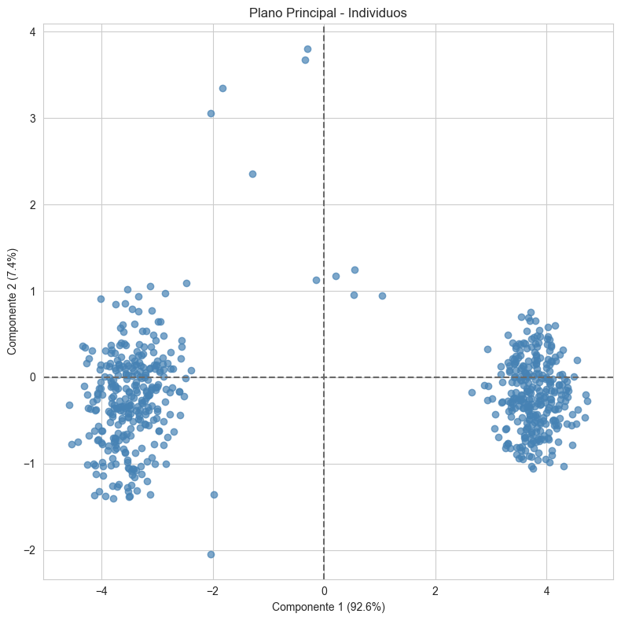

```python
fig_plano = acp.plano_principal(eje_x=0, eje_y=1)
```

### Parte 3

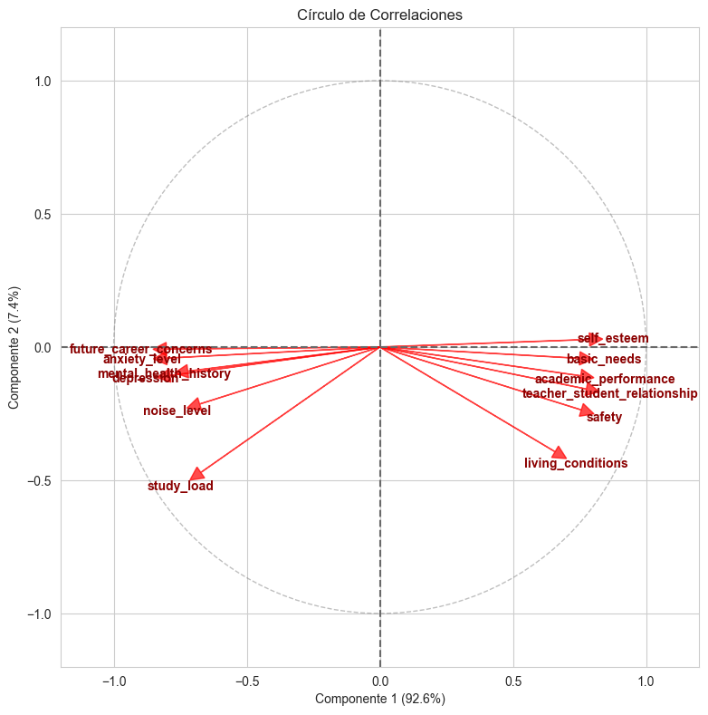

```python
fig_circulo = acp.circulo_correlacion(eje_x=0, eje_y=1)
plt.show()
```

### Parte 4

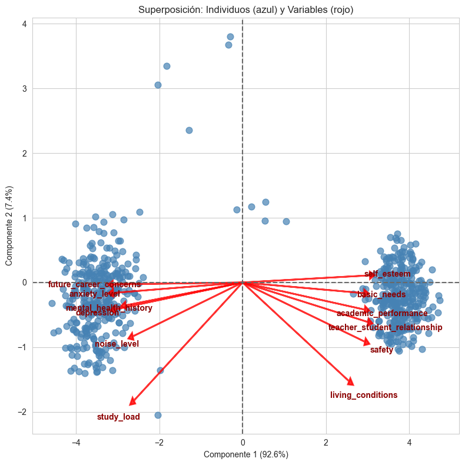

```python
fig_superposicion = acp.sobreposicion(eje_x=0, eje_y=1)
```